# Numerical Integration - PID Controller

This example explains how to take simulate the closed-loop response of a system with a PID controller, using basic numerical integration.

Consider the following system, $G_p=\dfrac{3(s+3)}{s^2+3s+15}$, for which we want to apply the controller $G_c=0.007(s+20)\dfrac{s+6}{s}$ in unity feedback.

If we want to simulate the closed-loop response to a step input, using the built-in functions, we first have to compute the closed-loop transfer function. $G_{cl}=\dfrac{G_cG_p}{1+G_cG_p}$

```
s =

  s

Continuous-time transfer function.


Gp =

     3 s + 9
  --------------
  s^2 + 3 s + 15

Continuous-time transfer function.


Gc =

  0.007 s^2 + 0.182 s + 0.84
  --------------------------
              s

Continuous-time transfer function.


Gcl =

  0.021 s^3 + 0.609 s^2 + 4.158 s + 7.56
  --------------------------------------
  1.021 s^3 + 3.609 s^2 + 19.16 s + 7.56

Continuous-time transfer function.
```

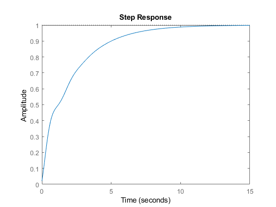

```matlab
s = tf("s")
Gp = 3*(s+3) / (s^2+3*s+15)
Gc = 0.007*(s+20)*(s+6)/s
Gcl = feedback(Gc*Gp, 1)
figure()
step(Gcl)
```

## PID Controller - Continuos Form

But we want to simulate the response through basic numerical integration. Let's look at the PID control law

$u(t)=K_P e(t) + K_I \int{e(t)dt} + K_D \dot{e}(t)$

And in code form

```
u[idx] = Kp*e[idx] + Ki*eint[idx] + Kd*edot[idx]
```

We can only find the integral and derivative of the error by numerical integration and differentiation respectively, this is really a discrete controller, it will not produce the same response as we got with `step()`, but will be close if $\Delta t$ is sufficiently small.

To find the error, error integral and error derivative numerically, where `r` is the reference and `y` is the output of the system, and `dt` is the time sample of the simulation.

```
e[idx] = r[idx] - y[idx]
eint[idx] = eint[idx-1]+ e[idx] * dt;
edot[idx] = (e[idx] - e[idx -1]) / dt;
```

Note that on the first iteration, can not access a negative index, so you can keep `eint[1]=e[1]*dt` and `edot[1]=0`, then apply the above rules for `idx>1`

### Transfer function to $\dot{\mathbf{x}}$

```
dxdt=@(t,x,u) [x(2); (-3*x(2)-15*x(1)+u)];
```

Where

```
y[idx] = 3*xdot[idx]+9*x[idx];
```

```
e[idx] = r[idx] - y[idx]
eint[idx] = eint[idx-1]+ e[idx] * dt;
edot[idx] = (e[idx] - e[idx -1]) / dt;
```

```
u[idx] = Kp*e[idx] + Ki*eint[idx] + Kd*edot[idx]
```

And there is no need to differentiate the input signal now.

Let's see how all this can be simulated. Note that the PID controller gains are $K_P=.182, K_D=0.007, K_I=0.84$

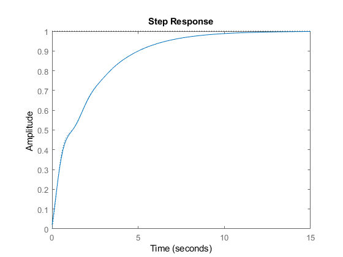

```matlab
dxdt=@(t,x,u) [x(2); (-3*x(2)-15*x(1)+u)];

% Integration time-step
dt = 0.01;

% Time vector
t = 0:dt:20;

% Initialize Simulation Vectors
x = zeros(2, length(t));
y = zeros(1, length(t));
u = zeros(1, length(t));
e = zeros(1, length(t));
edot = e;
eint = e;

% Initial Condition - Explicit Declaration
x0 = [0; 0];
x(:,1) = x0;

% Controller Gains
Kp=.182; Kd = 0.007; Ki=0.84;

% Step Input r = 1
r = 1;

% Simulate
for idx = 1:length(t)
    e(1, idx)   = r - y(1,idx);
    if idx == 1
        eint(1,idx) = e(1,idx) * dt; % Forward Integration
        edot(1,idx) = 0; % Skip on first iteration
    else
        eint(1,idx) = eint(1,idx-1) + e(1,idx) * dt;
        edot(1,idx) = (e(1,idx) - e(1, idx-1)) / dt;
    end
    u(1,idx) = Kp*e(1,idx) + Ki*eint(1,idx) + Kd*edot(1,idx);
    xdot = dxdt(t(1, idx), x(:,idx), u(1,idx));

    % Integrate state
    if(idx < length(t))
        x(:,idx+1) = x(:,idx) + xdot.*dt;
        % Scale output
        y(1, idx+1) = 9*x(1,idx+1)+3*x(2,idx+1);
    end

end

figure()
step(Gcl)
hold on
plot(t(1,1:end),y(1,1:end), ':')
```

## PID Controller - Discrete Form

A numerical integration simulation is a discrete system simulation, and converges into a continuous system for small $\Delta t$, in addition, differentiating signal boundaries results in errors, and basic numerical integration is insufficient.

Given a continous form PID controller $G_c=\dfrac{K_Ds^2+K_Ps+K_I}{s}$, we can convert it into a discrete form then derive the difference equation. This is outside the scope of this class, but here is difference equation for a PID controller.

[output not shown]

where

$a = K_P+K_I\dfrac{dt}{2} + \dfrac{K_D}{\Delta t}$

$b=-Kp + K_I \dfrac{\Delta t}{2} -2\dfrac{K_D}{\Delta t}$

$c=\dfrac{K_D}{\Delta t}$

Note that the discrete PID gains are a function of the continous PID gains in addition to the sampling (integration) time-step.

Substituting into the simulation setup, let's see how this would work.

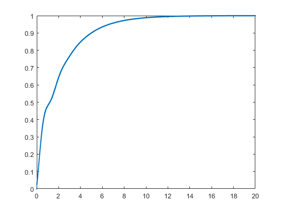

```matlab
dxdt=@(t,x,u) [x(2); (-3*x(2)-15*x(1)+u)];

% Integration time-step
dt = 0.01;

% Time vector
t = 0:dt:20;

% Initialize Simulation Vectors
x = zeros(2, length(t));
y = zeros(1, length(t));
u = zeros(1, length(t));
e = zeros(1, length(t));

% Initial Condition - Explicit Declaration
x0 = [0; 0];
x(:,1) = x0;

% Controller Gains
Kp=.182; Kd = 0.007; Ki=0.84;
% Discrete controller gains
a = Kp + Ki * dt / 2 + Kd / dt;
b = -Kp + Ki * dt / 2 - 2 * Kd / dt;
c = Kd/dt;

% Step Input r = 1
r = 1;

% Simulate
for idx = 1:length(t)
    e(1, idx)   = r - y(1,idx);
    if idx > 2
        u(1,idx) = u(1,idx-1) + a*e(1,idx) +b*e(1,idx-1) + c*e(1,idx-2);
    elseif idx == 2
        u(1,idx) = u(1,idx-1) + a*e(1,idx) +b*e(1,idx-1);
    elseif idx == 1
        u(1,idx) = a*e(1,idx);
    end
    xdot = dxdt(t(1, idx), x(:,idx), u(1,idx));
    % Integrate state
    if(idx < length(t))
        x(:,idx+1) = x(:,idx) + xdot*dt;
        % Scale output
        y(1, idx+1) = 9*x(1,idx+1)+3*x(2,idx+1);
    end
end
plot(t(1,1:end),y(1,1:end), '.-')
```